# AI CA4 REPORT

## Atieh Armin - 810197648

The goal of this computer assignment is to get acquainted with machine learning methods by SciKit-Learn library.

### Visualization and EDA

First the general structure of the data must be known.Describe() and info() are the functions that can show the structure. Describe() returns some general informations like mean, min, max and count and info() returns the datatype of every column in the dataframe.

```python
import pandas as pd

df = pd.read_csv("train.csv")

df.describe()
```

|  | Id | MSSubClass | LotFrontage | LotArea | OverallQual | OverallCond | YearBuilt | YearRemodAdd | MasVnrArea | BsmtFinSF1 | ... | WoodDeckSF | OpenPorchSF | EnclosedPorch | 3SsnPorch | ScreenPorch | PoolArea | MiscVal | MoSold | YrSold | SalePrice |
| --- | --- | --- | --- | --- | --- | --- | --- | --- | --- | --- | --- | --- | --- | --- | --- | --- | --- | --- | --- | --- | --- |
| count | 1460.000000 | 1460.000000 | 1201.000000 | 1460.000000 | 1460.000000 | 1460.000000 | 1460.000000 | 1460.000000 | 1452.000000 | 1460.000000 | ... | 1460.000000 | 1460.000000 | 1460.000000 | 1460.000000 | 1460.000000 | 1460.000000 | 1460.000000 | 1460.000000 | 1460.000000 | 1460.000000 |
| mean | 730.500000 | 56.897260 | 70.049958 | 10516.828082 | 6.099315 | 5.575342 | 1971.267808 | 1984.865753 | 103.685262 | 443.639726 | ... | 94.244521 | 46.660274 | 21.954110 | 3.409589 | 15.060959 | 2.758904 | 43.489041 | 6.321918 | 2007.815753 | 180921.195890 |
| std | 421.610009 | 42.300571 | 24.284752 | 9981.264932 | 1.382997 | 1.112799 | 30.202904 | 20.645407 | 181.066207 | 456.098091 | ... | 125.338794 | 66.256028 | 61.119149 | 29.317331 | 55.757415 | 40.177307 | 496.123024 | 2.703626 | 1.328095 | 79442.502883 |
| min | 1.000000 | 20.000000 | 21.000000 | 1300.000000 | 1.000000 | 1.000000 | 1872.000000 | 1950.000000 | 0.000000 | 0.000000 | ... | 0.000000 | 0.000000 | 0.000000 | 0.000000 | 0.000000 | 0.000000 | 0.000000 | 1.000000 | 2006.000000 | 34900.000000 |
| 25% | 365.750000 | 20.000000 | 59.000000 | 7553.500000 | 5.000000 | 5.000000 | 1954.000000 | 1967.000000 | 0.000000 | 0.000000 | ... | 0.000000 | 0.000000 | 0.000000 | 0.000000 | 0.000000 | 0.000000 | 0.000000 | 5.000000 | 2007.000000 | 129975.000000 |
| 50% | 730.500000 | 50.000000 | 69.000000 | 9478.500000 | 6.000000 | 5.000000 | 1973.000000 | 1994.000000 | 0.000000 | 383.500000 | ... | 0.000000 | 25.000000 | 0.000000 | 0.000000 | 0.000000 | 0.000000 | 0.000000 | 6.000000 | 2008.000000 | 163000.000000 |
| 75% | 1095.250000 | 70.000000 | 80.000000 | 11601.500000 | 7.000000 | 6.000000 | 2000.000000 | 2004.000000 | 166.000000 | 712.250000 | ... | 168.000000 | 68.000000 | 0.000000 | 0.000000 | 0.000000 | 0.000000 | 0.000000 | 8.000000 | 2009.000000 | 214000.000000 |
| max | 1460.000000 | 190.000000 | 313.000000 | 215245.000000 | 10.000000 | 9.000000 | 2010.000000 | 2010.000000 | 1600.000000 | 5644.000000 | ... | 857.000000 | 547.000000 | 552.000000 | 508.000000 | 480.000000 | 738.000000 | 15500.000000 | 12.000000 | 2010.000000 | 755000.000000 |

8 rows × 38 columns

```python
df.info(verbose=True)
```

```
<class 'pandas.core.frame.DataFrame'>
RangeIndex: 1460 entries, 0 to 1459
Data columns (total 81 columns):
 #   Column         Non-Null Count  Dtype
---  ------         --------------  -----
 0   Id             1460 non-null   int64
 1   MSSubClass     1460 non-null   int64
 2   MSZoning       1460 non-null   object
 3   LotFrontage    1201 non-null   float64
 4   LotArea        1460 non-null   int64
 5   Street         1460 non-null   object
 6   Alley          91 non-null     object
 7   LotShape       1460 non-null   object
 8   LandContour    1460 non-null   object
 9   Utilities      1460 non-null   object
```

[output cut: 73 more lines]

##### Missing Values

```python
values = {'Alley': 'NOTEX', 'BsmtQual':'NOTEX', 'BsmtCond':'NOTEX', 'BsmtExposure':'NOTEX', 'BsmtFinType1':'NOTEX',
          'BsmtFinType2':'NOTEX', 'FireplaceQu':'NOTEX', 'GarageType': 'NOTEX', 'GarageFinish': 'NOTEX',
          'GarageQual': 'NOTEX', 'GarageCond': 'NOTEX', 'PoolQC': 'NOTEX', 'Fence': 'NOTEX', 'MiscFeature': 'NOTEX'}
df.fillna(value = values, inplace = True)
missing_data = df.isna().sum() / len(df) * 100
for i in range (len(missing_data)):
    print(df.columns[i]," :",missing_data[i])
```

```
Id  : 0.0
MSSubClass  : 0.0
MSZoning  : 0.0
LotFrontage  : 17.73972602739726
LotArea  : 0.0
Street  : 0.0
Alley  : 0.0
LotShape  : 0.0
LandContour  : 0.0
Utilities  : 0.0
LotConfig  : 0.0
LandSlope  : 0.0
Neighborhood  : 0.0
Condition1  : 0.0
Condition2  : 0.0
BldgType  : 0.0
HouseStyle  : 0.0
OverallQual  : 0.0
OverallCond  : 0.0
YearBuilt  : 0.0
YearRemodAdd  : 0.0
RoofStyle  : 0.0
RoofMatl  : 0.0
Exterior1st  : 0.0
Exterior2nd  : 0.0
MasVnrType  : 0.547945205479452
MasVnrArea  : 0.547945205479452
ExterQual  : 0.0
ExterCond  : 0.0
Foundation  : 0.0
BsmtQual  : 0.0
BsmtCond  : 0.0
BsmtExposure  : 0.0
BsmtFinType1  : 0.0
BsmtFinSF1  : 0.0
BsmtFinType2  : 0.0
BsmtFinSF2  : 0.0
BsmtUnfSF  : 0.0
TotalBsmtSF  : 0.0
Heating  : 0.0
```

[output cut: 26 more lines]

```
WoodDeckSF  : 0.0
OpenPorchSF  : 0.0
EnclosedPorch  : 0.0
3SsnPorch  : 0.0
ScreenPorch  : 0.0
PoolArea  : 0.0
PoolQC  : 0.0
Fence  : 0.0
MiscFeature  : 0.0
MiscVal  : 0.0
MoSold  : 0.0
YrSold  : 0.0
SaleType  : 0.0
SaleCondition  : 0.0
SalePrice  : 0.0
```

##### Heatmap

Heatmap() function is used to see the correlation between features. Here we can see that the lighter the color of the heatmap is, the stronger the correlation between features is. The number that is in every cell of the heatmap shows the number of data or colleration of the data.

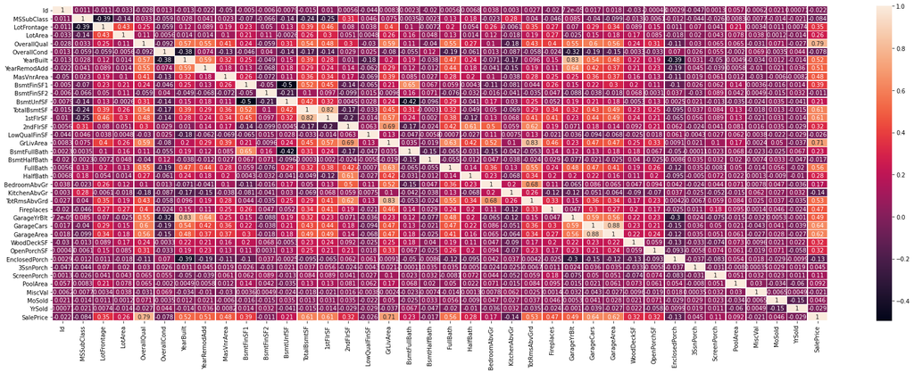

```python
import seaborn as sn
import matplotlib.pyplot as plt

fig, ax = plt.subplots(figsize=(30,10))
corr = df.corr()
sn.heatmap(corr, linewidths=.5, annot = True)
```

Applying the natural log transformation function to the SalePrice column will change the number of some cells of the SalePrice column in the heatmap. Some numbers become greater and shows that the correlation is stronger and some become lower and shows that the correlation is weaker. The most common method of correlation is Pearson's correlation coefficient, which measures the amount of linear dependence between two vectors. The default method of corr() function is also Pearson's method. It essentially lays a straight line through the scatterplot and calculates its slope. Thus, it will change if you take logs.

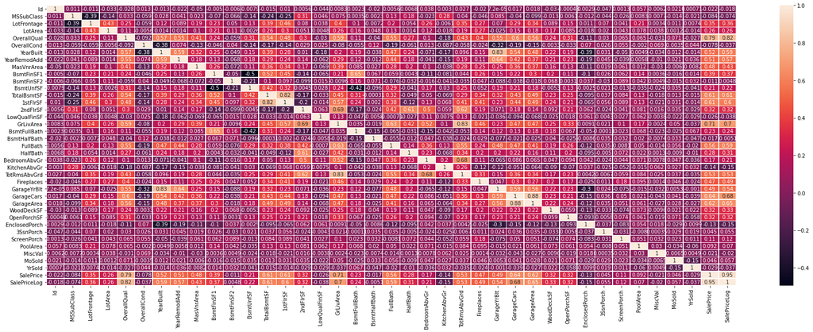

```python
import numpy as np

df['SalePriceLog'] = np.log(df['SalePrice'])
fig, ax = plt.subplots(figsize=(30,10))
corr = df.corr()
sn.heatmap(corr, linewidths=.5, annot = True)
del df['SalePriceLog']
```

It is obvious that this heatmap just shows the features that are numeric because of the corr() function (correlation can be used for numeric data).

We can undrestand that "OverallQual", "GrLivArea", "GarageCars" and "GarageArea" are four features that have the most effect on "SalePrice" features. The relationship between these features and "SalePrice" is better illustrated by the following diagrams.  
Scatter diagram is a type of plot or mathematical diagram using Cartesian coordinates to display values for typically two variables for a set of data. A Hexbin plot is useful to represent the relationship of 2 numerical variables when you have a lot of data point. Instead of overlapping, the plotting window is split in several hexbins, and the number of points per hexbin is counted.

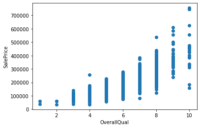

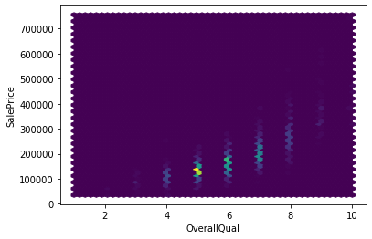

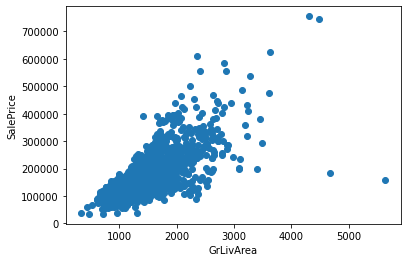

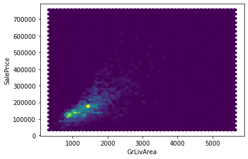

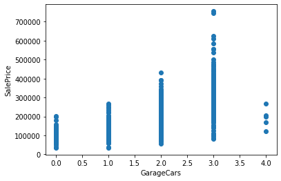

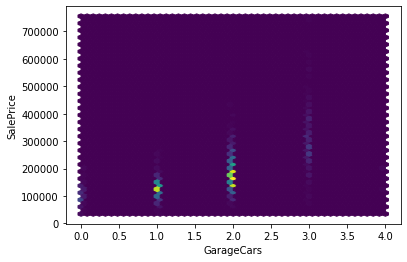

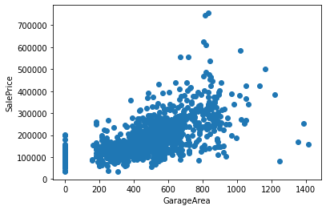

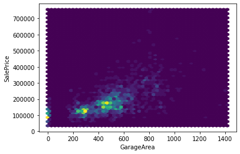

```python
plt.scatter(df['OverallQual'],df['SalePrice'])
plt.xlabel('OverallQual')
plt.ylabel('SalePrice')
plt.show()
plt.hexbin(df['OverallQual'], df['SalePrice'],gridsize=50)
plt.xlabel('OverallQual')
plt.ylabel('SalePrice')
plt.show()
plt.scatter(df['GrLivArea'],df['SalePrice'])
plt.xlabel('GrLivArea')
plt.ylabel('SalePrice')
plt.show()
plt.hexbin(df['GrLivArea'], df['SalePrice'],gridsize=50)
plt.xlabel('GrLivArea')
plt.ylabel('SalePrice')
plt.show()
plt.scatter(df['GarageCars'],df['SalePrice'])
plt.xlabel('GarageCars')
plt.ylabel('SalePrice')
plt.show()
plt.hexbin(df['GarageCars'], df['SalePrice'],gridsize=50)
plt.xlabel('GarageCars')
plt.ylabel('SalePrice')
plt.show()
plt.scatter(df['GarageArea'],df['SalePrice'])
plt.xlabel('GarageArea')
plt.ylabel('SalePrice')
plt.show()
plt.hexbin(df['GarageArea'], df['SalePrice'],gridsize=50)
plt.xlabel('GarageArea')
plt.ylabel('SalePrice')
plt.show()
```

You can guess that "YearBuilt", "YearRemodAdd" and "TotRmsAbvGrd" may be effective on "SalePrice" by checking the data description file and also if you have ever bought a house you can tell that these features are important in home pricing.  
As shown in the diagrams bellow, these features also has significant impact on home prices.

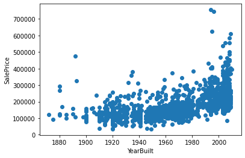

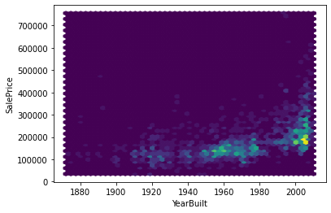

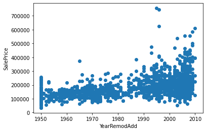

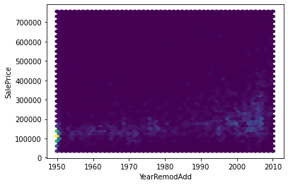

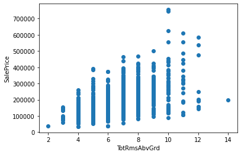

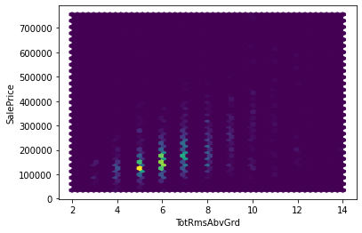

```python
plt.scatter(df['YearBuilt'],df['SalePrice'])
plt.xlabel('YearBuilt')
plt.ylabel('SalePrice')
plt.show()
plt.hexbin(df['YearBuilt'], df['SalePrice'],gridsize=50)
plt.xlabel('YearBuilt')
plt.ylabel('SalePrice')
plt.show()
plt.scatter(df['YearRemodAdd'],df['SalePrice'])
plt.xlabel('YearRemodAdd')
plt.ylabel('SalePrice')
plt.show()
plt.hexbin(df['YearRemodAdd'], df['SalePrice'],gridsize=50)
plt.xlabel('YearRemodAdd')
plt.ylabel('SalePrice')
plt.show()
plt.scatter(df['TotRmsAbvGrd'],df['SalePrice'])
plt.xlabel('TotRmsAbvGrd')
plt.ylabel('SalePrice')
plt.show()
plt.hexbin(df['TotRmsAbvGrd'], df['SalePrice'],gridsize=50)
plt.xlabel('TotRmsAbvGrd')
plt.ylabel('SalePrice')
plt.show()
```

### Preprocessing

##### Handling Missing Data

A number of alternative ways of handling the missing data has been developed. Dropping a column which has a lot of missing data is one of the ways of handling missing data but it is not a good way for every column in the dataframe because suppose we have a column which have only 0.05% missing data, we can not drop this data because of this amount of missing data because it may have important information. But if there is a column with 20% missing data, it can be dropped.  
Another way to handle missing data is to use the mean value of a variable in place of the missing data value for that same variable. This can be used for only numeric features.  
Regression imputation is another way of handling missing data which the existing variables are used to make a prediction, and then the predicted value is substituted as if an actual obtained value. This may be better way compare to replace missing data with mean value of the column because when we use every available data to predict the missing data, that prediction can be very accurate and very close to the actual value of that data.  
For non numeric featuresattribiutes it is hard to use the last two ways mentioned above. One way to handle missing data in these columns is to replace them with the most repetitive value in the column.

In last section we saw that "LotFrontage" and "GarageYrBlt" has the most missing data among all the columns. Thus dropping them won't be a problem.

```python
def handle_missing_data(df):
    values = {'Alley': 'NOTEX', 'BsmtQual':'NOTEX', 'BsmtCond':'NOTEX', 'BsmtExposure':'NOTEX', 'BsmtFinType1':'NOTEX',
          'BsmtFinType2':'NOTEX', 'FireplaceQu':'NOTEX', 'GarageType': 'NOTEX', 'GarageFinish': 'NOTEX',
          'GarageQual': 'NOTEX', 'GarageCond': 'NOTEX', 'PoolQC': 'NOTEX', 'Fence': 'NOTEX', 'MiscFeature': 'NOTEX'}
    df.fillna(value = values, inplace = True)
    df.drop(columns = ['LotFrontage','GarageYrBlt'],inplace = True)
    for (columnName, columnData) in df.iteritems():
        if(df[columnName].isna().any()):
            if(df[columnName].dtypes == 'object'):
                val_count = df[columnName].value_counts()
                df[columnName].fillna(val_count.idxmax(),inplace = True)
            else:
                df[columnName].fillna(df[columnName].mean(),inplace = True)
```

##### Delete Unnecessary Features

In visualisation and EDA section we saw the correlation heatmap. The features that has the minimum correlation with "SalePrice" - the target value of this project - can be easily deleted.

```python
def delete_unnecessary_features(df):
    limit = 0.2
    for col in df.columns:
        if df.corr()['SalePrice'][col] < limit:
            if col == 'Id':
                continue
            df.drop(col, inplace = True, axis = 1)
```

##### Normalizing and Standardizing

Data normalization is used to make model training less sensitive to the scale of features and makes the data better conditioned for convergence. In general, the goal of normalization is to change the values of numeric columns in the dataset to a common scale, without distorting differences in the ranges of values.

Standardizing the features around the center and 0 with a standard deviation of 1 is important when we compare measurements that have different units. Variables that are measured at different scales do not contribute equally to the analysis and might end up creating a bais.

```python
from sklearn import preprocessing
from pandas.plotting import andrews_curves

def normalizing_and_standardizing(df):
    num_cols = []

    for col in df.columns[df.dtypes.apply(lambda c: np.issubdtype(c, np.number))]:
        if ((col != 'Id') and (col != 'SalePrice')):
            num_cols.append(col)

    normalized_df = df.copy()
    normalized_df[num_cols] = preprocessing.normalize(normalized_df[num_cols])


    standardiser = preprocessing.StandardScaler()
    standardised_df = df.copy()
    standardised_df[num_cols] = standardiser.fit_transform(standardised_df[num_cols])
    return normalized_df, standardised_df
```

##### Categorical Featue Encoding

There are 3 different types of categorical data:

Binary

Binary features are those with only two possible values. The values of these features can easly replace with two numbers (0,1) using replace() function.

Ordinal

Ordinal features are those with some order associated with them. The values of these features also can replace with numbers (integer encoding) which the order of them will show the order of the values of the feature. Map() will map the numbers to the labels.

Nominal

Nominal features are categorical features that have no numerical importance. One-hot encoding can be used to encode these features. In this encoding, a new binary column is created for every value that the feature can get and for each of them the column corresponding to that value gets 1 and the others get 0.

```python
def categorical_encoding(df):
    ordinal_dict = {"Ex": 5, "Gd": 4, "TA": 3, "Fa": 2, "Po": 1, "NOTEX": 0,
               "MnWw":4, "GdWo":3, "MnPrv":2, "GdPrv":1,
               "Fin":3, "RFn":2, "Unf":1,
               "Y":1, "N":0,
               "GLQ":6, "ALQ":5, "BLQ":4, "Rec":3, "LwQ":2, "Unf":1,
               "Av":3, "Mn":2, "No":1,
               "Gtl":3, "Mod":2, "Sev":1,
               "AllPub":4, "NoSewr":3, "NoSeWa":2, "ELO":1,
               "Reg":4, "IR1":3, "IR2":2, "IR3":1,
               "Grvl":2, "Pave":1}
    df['Street'] = df.Street.map(ordinal_dict)
    df['Alley'] = df.Alley.map(ordinal_dict)
    df['LotShape'] = df.LotShape.map(ordinal_dict)
    df['Utilities'] = df.Utilities.map(ordinal_dict)
    df['LandSlope'] = df.LandSlope.map(ordinal_dict)
    df['ExterQual'] = df.ExterQual.map(ordinal_dict)
    df['ExterCond'] = df.ExterCond.map(ordinal_dict)
    df['BsmtQual'] = df.BsmtQual.map(ordinal_dict)
    df['BsmtCond'] = df.BsmtCond.map(ordinal_dict)
    df['BsmtExposure'] = df.BsmtExposure.map(ordinal_dict)
    df['BsmtFinType1'] = df.BsmtFinType1.map(ordinal_dict)
    df['BsmtFinType2'] = df.BsmtFinType2.map(ordinal_dict)
    df['HeatingQC'] = df.HeatingQC.map(ordinal_dict)
    df['CentralAir'] = df.CentralAir.map(ordinal_dict)
    df['KitchenQual'] = df.KitchenQual.map(ordinal_dict)
    df['FireplaceQu'] = df.FireplaceQu.map(ordinal_dict)
    df['GarageFinish'] = df.GarageFinish.map(ordinal_dict)
    df['GarageQual'] = df.GarageQual.map(ordinal_dict)
    df['GarageCond'] = df.GarageCond.map(ordinal_dict)
    df['PoolQC'] = df.PoolQC.map(ordinal_dict)
    df['Fence'] = df.Fence.map(ordinal_dict)

    nominal_features = []
    for col in df.columns:
        if df[col].dtypes == 'object':
            nominal_features.append(col)
    df = pd.get_dummies(df, columns = nominal_features, drop_first = True)
    return df
```

##### Cross Validation

Once training the model is done, it should be evaluated to assume that it is going to work well on data that it has not seen before.  
Testing any machine learning model on some unseen data is a way to evaluate the performance of it. Based on the models performance on unseen data we can say weather our model is Under-fitting/Over-fitting/Well generalized. Cross validation (CV) is one of the technique used to test the effectiveness of a machine learning models, it is also a re-sampling procedure used to evaluate a model if we have a limited data. Cross validation is one of the technique used to test the effectiveness of a machine learning models, it is also a re-sampling procedure used to evaluate a model if we have a limited data.

Common techniques used for cross validation:

Leave p-out cross-validation:

This technique involves using p-observation as validation data, and remaining data is used to train the model.

Leave-one-out cross-validation:

For a model having n samples, first sample is selected for validation and the rest (n-1) samples are used to train the model. For next iteration, second sample is selected for validation and rest to train the model. And this process continues in the same way.

Holdout cross-validation:

In this technique, dataset is randomly split into training and validation data. You should know that the more data is used to train the model, the better the model is.  
With this approach there is a possibility of high bias if we have limited data, because we would miss some information about the data which we have not used for training.

K-fold cross-validation:

The original dataset is equally partitioned into k subsets. For each iteration, one of the k subsets or folds is selected as validation data and the remaining subsets are selected as training data. The process is repeated for k times until each group is once trated as validation data.

Repeated random subsampling validation:

In this technique, dataset randomly split into training and validation subsets and this random subsampling validation is repeated in a row. One of the disadvantages of this method is that some samples may not be selected for either training or validation.

Here, holdout cross-validation is used by train_test_split() function.

```python
from sklearn.model_selection import train_test_split
def split(df):
    train, validation = train_test_split(df, test_size = 0.3, random_state = 42, shuffle = True)
    return train, validation
```

### Overfitting and Underfitting

Formally, overfitting referes to the situation where a model learns the data but also the noise that is part of training data to the extent that it negatively impacts the performance of the model on new unseen data.  
A model that underfits the data will have poor performance on the training data.

### Model Training, Evaluation and Hyperparameter Tuning

Here are the implementations of three models: K-Nearest-Neighbers, Decision Tree and Linear Regression.  
K-Nearest-Neighbers and Decision Tree has a several hyperpatameters. Thus, each of them runs with a bunch of different hyperparameter and two criteria - MAE and RMSE - are measured every time for train and validation set. There is two diagram showing the MAE and RMSE for both validarion and train set.  
On the other hand, Running Linear Regression for several times does not change the value of MAE or RMSE.

##### K-Nearest-Neighbers

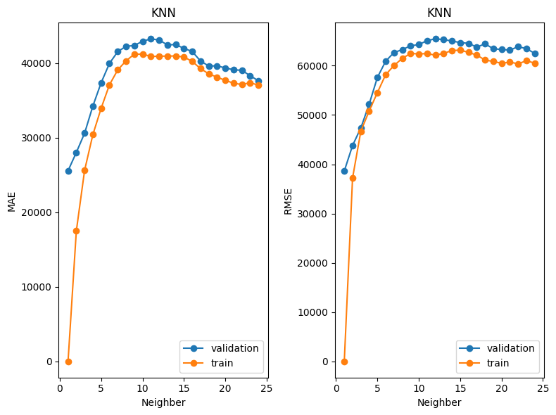

```python
from sklearn.neighbors import KNeighborsClassifier

from sklearn.metrics import mean_absolute_error, mean_squared_error

plt.figure(num=None, figsize=(8, 6), dpi=100, facecolor='w', edgecolor='k')

def KNN(df,hyper_param_grid):
    train_df, validation_df = split(df)
    train_inputs = train_df.drop(columns=['SalePrice','Id'])
    train_target = train_df['SalePrice'].values
    validation_target = validation_df['SalePrice'].values
    validation_inputs = validation_df.drop(columns=['SalePrice','Id'])

    validation_MAE = []
    validation_RMSE = []
    train_MAE = []
    train_RMSE = []
    for k in hyper_param_grid:
        k_neighbors = KNeighborsClassifier(n_neighbors = k)
        k_neighbors.fit(train_inputs,train_target)

        validation_pred = k_neighbors.predict(validation_inputs)
        train_pred = k_neighbors.predict(train_inputs)

        validation_MAE.append(mean_absolute_error(validation_target,validation_pred))
        validation_RMSE.append(mean_squared_error(validation_target, validation_pred, squared=False))
        train_MAE.append(mean_absolute_error(train_target,train_pred))
        train_RMSE.append(mean_squared_error(train_target, train_pred, squared=False))


    plt.subplot(1,2,1)
    plt.plot(hyper_param_grid, np.array(validation_MAE).ravel(), 'o-', label='validation')
    plt.plot(hyper_param_grid, np.array(train_MAE).ravel(), 'o-', label='train')
    plt.xlabel('Neighber')
    plt.ylabel('MAE')
    plt.title('KNN')
    plt.tight_layout()
    plt.legend()

    plt.subplot(1,2,2)
    plt.plot(hyper_param_grid, np.array(validation_RMSE).ravel(), 'o-', label='validation')
    plt.plot(hyper_param_grid, np.array(train_RMSE).ravel(), 'o-', label='train')
    plt.xlabel('Neighber')
    plt.ylabel('RMSE')
    plt.title('KNN')
    plt.tight_layout()
    plt.legend()

    plt.show()


df = pd.read_csv("train.csv")
handle_missing_data(df)
df = categorical_encoding(df)
normalized_df, standardized_df = normalizing_and_standardizing(df)
delete_unnecessary_features(standardized_df)
hyper_param_grid = np.arange(1, 25)
KNN(standardized_df, hyper_param_grid)
```

##### Decision Tree

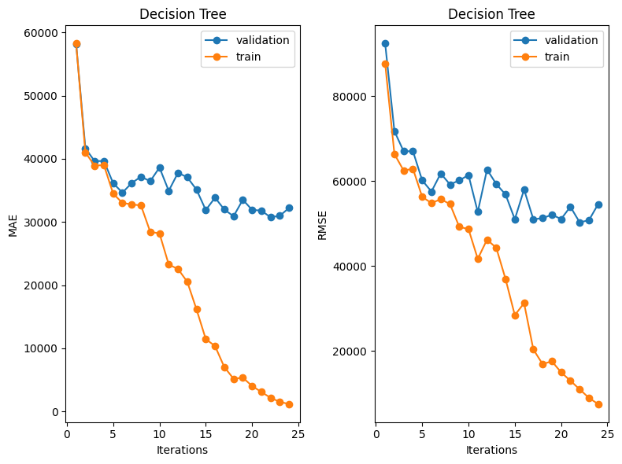

```python
from sklearn.tree import DecisionTreeClassifier

plt.figure(num=None, figsize=(8, 6), dpi=100, facecolor='w', edgecolor='k')


def decision_tree(df,depth_range):
    train_df, validation_df = split(df)
    train_inputs = train_df.drop(columns=['SalePrice','Id'])
    train_target = train_df['SalePrice'].values
    validation_target = validation_df['SalePrice'].values
    validation_inputs = validation_df.drop(columns=['SalePrice','Id'])

    validation_MAE = []
    validation_RMSE = []
    train_MAE = []
    train_RMSE = []
    for i in depth_range:
        decision_tree_classifier= DecisionTreeClassifier(random_state = 42, max_depth=i)
        decision_tree_classifier = decision_tree_classifier.fit(train_inputs,train_target)
        validation_pred = decision_tree_classifier.predict(validation_inputs)
        train_pred = decision_tree_classifier.predict(train_inputs)

        validation_MAE.append(mean_absolute_error(validation_target,validation_pred))
        validation_RMSE.append(mean_squared_error(validation_target, validation_pred, squared=False))
        train_MAE.append(mean_absolute_error(train_target,train_pred))
        train_RMSE.append(mean_squared_error(train_target, train_pred, squared=False))

    plt.subplot(1,2,1)
    plt.plot(depth_range, np.array(validation_MAE).ravel(), 'o-', label='validation')
    plt.plot(depth_range, np.array(train_MAE).ravel(), 'o-', label='train')
    plt.xlabel('Iterations')
    plt.ylabel('MAE')
    plt.title('Decision Tree')
    plt.tight_layout()
    plt.legend()

    plt.subplot(1,2,2)
    plt.plot(depth_range, np.array(validation_RMSE).ravel(), 'o-', label='validation')
    plt.plot(depth_range, np.array(train_RMSE).ravel(), 'o-', label='train')
    plt.xlabel('Iterations')
    plt.ylabel('RMSE')
    plt.title('Decision Tree')
    plt.tight_layout()
    plt.legend()

    plt.show()

df = pd.read_csv("train.csv")
handle_missing_data(df)
df = categorical_encoding(df)
normalized_df, standardized_df = normalizing_and_standardizing(df)
delete_unnecessary_features(standardized_df)
depth_range = np.arange(1, 25)
decision_tree(standardized_df,depth_range)
```

```python
from sklearn.linear_model import LinearRegression

def linear_regression(df):
    train_df, validation_df = split(df)
    train_inputs = train_df.drop(columns=['SalePrice','Id'])
    train_target = train_df['SalePrice'].values
    validation_target = validation_df['SalePrice'].values
    validation_inputs = validation_df.drop(columns=['SalePrice','Id'])

    reg = LinearRegression()
    reg = reg.fit(train_inputs, train_target)
    validation_pred = reg.predict(validation_inputs)
    train_pred = reg.predict(train_inputs)

    print ('validation MAE: ' , mean_absolute_error(validation_target,validation_pred))
    print ('validation RMSE: ' , mean_squared_error(validation_target, validation_pred, squared=False))
    print ('train MAE: ' , mean_absolute_error(train_target,train_pred))
    print ('train RMSE: ' , mean_squared_error(train_target, train_pred, squared=False))

df = pd.read_csv("train.csv")
handle_missing_data(df)
df = categorical_encoding(df)
normalized_df, standardized_df = normalizing_and_standardizing(df)
delete_unnecessary_features(standardized_df)
linear_regression(standardized_df)
```

```
validation MAE:  20720.50776172095
validation RMSE:  32088.890640174875
train MAE:  20358.061843265263
train RMSE:  32090.432819968915
```

### Ensemble Methods

Ensemble methods are techniques that create multiple models and then combine them to produce improved results. Ensemble methods usually produces more accurate solutions than a single model would. This has been the case in a number of machine learning competitions, where the winning solutions used ensemble methods.  
In this project, two ensemble methods are used: Random Forest and Voting Regression

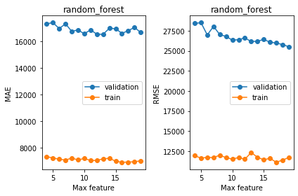

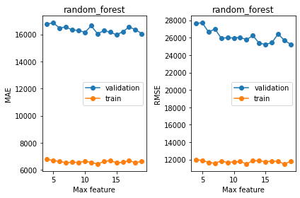

```python
from sklearn.ensemble import RandomForestRegressor

def random_forest(df,estimators,max_features_range):
    train_df, validation_df = split(df)
    train_inputs = train_df.drop(columns=['SalePrice','Id'])
    train_target = train_df['SalePrice'].values
    validation_target = validation_df['SalePrice'].values
    validation_inputs = validation_df.drop(columns=['SalePrice','Id'])

    validation_MAE = []
    validation_RMSE = []
    train_MAE = []
    train_RMSE = []
    for i in max_features_range:
        random_forest_reg = RandomForestRegressor(n_estimators = estimators,max_features = i , random_state = 42)
        random_forest_reg.fit(train_inputs, train_target);
        validation_pred = random_forest_reg.predict(validation_inputs)
        train_pred = random_forest_reg.predict(train_inputs)

        validation_MAE.append(mean_absolute_error(validation_target,validation_pred))
        validation_RMSE.append(mean_squared_error(validation_target, validation_pred, squared=False))
        train_MAE.append(mean_absolute_error(train_target,train_pred))
        train_RMSE.append(mean_squared_error(train_target, train_pred, squared=False))

    plt.subplot(1,2,1)
    plt.plot(max_features_range, np.array(validation_MAE).ravel(), 'o-', label='validation')
    plt.plot(max_features_range, np.array(train_MAE).ravel(), 'o-', label='train')
    plt.xlabel('Max feature')
    plt.ylabel('MAE')
    plt.title('random_forest')
    plt.tight_layout()
    plt.legend()

    plt.subplot(1,2,2)
    plt.plot(max_features_range, np.array(validation_RMSE).ravel(), 'o-', label='validation')
    plt.plot(max_features_range, np.array(train_RMSE).ravel(), 'o-', label='train')
    plt.xlabel('Max feature')
    plt.ylabel('RMSE')
    plt.title('random_forest')
    plt.tight_layout()
    plt.legend()

    plt.show()

df = pd.read_csv("train.csv")
handle_missing_data(df)
df = categorical_encoding(df)
normalized_df, standardized_df = normalizing_and_standardizing(df)
delete_unnecessary_features(standardized_df)
max_features_range = np.arange(4,20)
estimators = 25
random_forest(standardized_df,estimators,max_features_range)
estimators = 100
random_forest(standardized_df,estimators,max_features_range)
```

```python
from sklearn.ensemble import VotingRegressor

def voting_regression(df):
    train_df, validation_df = split(df)
    train_inputs = train_df.drop(columns=['SalePrice','Id'])
    train_target = train_df['SalePrice'].values
    validation_target = validation_df['SalePrice'].values
    validation_inputs = validation_df.drop(columns=['SalePrice','Id'])

    k_neighbors = KNeighborsRegressor(n_neighbors = 3)
    k_neighbors.fit(train_inputs,train_target)

    decision_tree_classifier= DecisionTreeRegressor(max_depth=14, random_state  = 42)
    decision_tree_classifier = decision_tree_classifier.fit(train_inputs,train_target)

    reg = LinearRegression()
    reg = reg.fit(train_inputs, train_target)

    est = [('k_neighbors', k_neighbors), ('decision_tree_classifier', decision_tree_classifier), ('reg', reg)]
    voting = VotingRegressor(est)
    voting = voting.fit(train_inputs, train_target)

    validation_pred = voting.predict(validation_inputs)
    train_pred = voting.predict(train_inputs)

    print ('validation MAE: ' , mean_absolute_error(validation_target,validation_pred))
    print ('validation RMSE: ' , mean_squared_error(validation_target, validation_pred, squared=False))
    print ('train MAE: ' , mean_absolute_error(train_target,train_pred))
    print ('train RMSE: ' , mean_squared_error(train_target, train_pred, squared=False))


df = pd.read_csv("train.csv")
handle_missing_data(df)
df = categorical_encoding(df)
normalized_df, standardized_df = normalizing_and_standardizing(df)
delete_unnecessary_features(standardized_df)
voting_regression(standardized_df)
```

```
validation MAE:  18057.3422712569
validation RMSE:  27794.46413570218
train MAE:  11049.454705982609
train RMSE:  18338.77113673472
```